# fordgobike_analysis

```python
import pandas as pd
import matplotlib.pyplot as plt
import numpy as np
import seaborn as sb
import datetime
% matplotlib inline
```

## Gathering and Assessing the data

> The raw data is a year and month wise distributed, except for the 2017 data- which is consolidated to one file. Clubing all the data of all the months to one file.

```python
ford_df=[]
files=["2017-fordgobike-tripdata.csv","201801-fordgobike-tripdata.csv" , "201802-fordgobike-tripdata.csv",
       "201803-fordgobike-tripdata.csv", "201804-fordgobike-tripdata.csv","201805-fordgobike-tripdata.csv",
       "201806-fordgobike-tripdata.csv", "201807-fordgobike-tripdata.csv", "201808-fordgobike-tripdata.csv",
       "201809-fordgobike-tripdata.csv", "201810-fordgobike-tripdata.csv","201811-fordgobike-tripdata.csv",
       "201812-fordgobike-tripdata.csv","201901-fordgobike-tripdata.csv","201902-fordgobike-tripdata.csv"]
for f in files:
    ford_df.append(pd.read_csv(f))
ford_df=pd.concat(ford_df, sort=False)
```

```python
ford_df.info()
```

```
<class 'pandas.core.frame.DataFrame'>
Int64Index: 2758915 entries, 0 to 183411
Data columns (total 16 columns):
duration_sec               int64
start_time                 object
end_time                   object
start_station_id           float64
start_station_name         object
start_station_latitude     float64
start_station_longitude    float64
end_station_id             float64
end_station_name           object
end_station_latitude       float64
end_station_longitude      float64
bike_id                    int64
user_type                  object
member_birth_year          float64
member_gender              object
bike_share_for_all_trip    object
dtypes: float64(7), int64(2), object(7)
memory usage: 357.8+ MB
```

```python
ford_df.head()
```

|  | duration_sec | start_time | end_time | start_station_id | start_station_name | start_station_latitude | start_station_longitude | end_station_id | end_station_name | end_station_latitude | end_station_longitude | bike_id | user_type | member_birth_year | member_gender | bike_share_for_all_trip |
| --- | --- | --- | --- | --- | --- | --- | --- | --- | --- | --- | --- | --- | --- | --- | --- | --- |
| 0 | 80110 | 2017-12-31 16:57:39.6540 | 2018-01-01 15:12:50.2450 | 74.0 | Laguna St at Hayes St | 37.776435 | -122.426244 | 43.0 | San Francisco Public Library (Grove St at Hyde... | 37.778768 | -122.415929 | 96 | Customer | 1987.0 | Male | NaN |
| 1 | 78800 | 2017-12-31 15:56:34.8420 | 2018-01-01 13:49:55.6170 | 284.0 | Yerba Buena Center for the Arts (Howard St at ... | 37.784872 | -122.400876 | 96.0 | Dolores St at 15th St | 37.766210 | -122.426614 | 88 | Customer | 1965.0 | Female | NaN |
| 2 | 45768 | 2017-12-31 22:45:48.4110 | 2018-01-01 11:28:36.8830 | 245.0 | Downtown Berkeley BART | 37.870348 | -122.267764 | 245.0 | Downtown Berkeley BART | 37.870348 | -122.267764 | 1094 | Customer | NaN | NaN | NaN |
| 3 | 62172 | 2017-12-31 17:31:10.6360 | 2018-01-01 10:47:23.5310 | 60.0 | 8th St at Ringold St | 37.774520 | -122.409449 | 5.0 | Powell St BART Station (Market St at 5th St) | 37.783899 | -122.408445 | 2831 | Customer | NaN | NaN | NaN |
| 4 | 43603 | 2017-12-31 14:23:14.0010 | 2018-01-01 02:29:57.5710 | 239.0 | Bancroft Way at Telegraph Ave | 37.868813 | -122.258764 | 247.0 | Fulton St at Bancroft Way | 37.867789 | -122.265896 | 3167 | Subscriber | 1997.0 | Female | NaN |

```python
ford_df.describe()
```

|  | duration_sec | start_station_id | start_station_latitude | start_station_longitude | end_station_id | end_station_latitude | end_station_longitude | bike_id | member_birth_year |
| --- | --- | --- | --- | --- | --- | --- | --- | --- | --- |
| count | 2.758915e+06 | 2.746699e+06 | 2.758915e+06 | 2.758915e+06 | 2.746699e+06 | 2.758915e+06 | 2.758915e+06 | 2.758915e+06 | 2.563671e+06 |
| mean | 8.867051e+02 | 1.171937e+02 | 3.776846e+01 | -1.223528e+02 | 1.153725e+02 | 3.776860e+01 | -1.223523e+02 | 2.444508e+03 | 1.982807e+03 |
| std | 2.539867e+03 | 1.000814e+02 | 1.010326e-01 | 1.495794e-01 | 9.994630e+01 | 1.009225e-01 | 1.491726e-01 | 1.493081e+03 | 1.047972e+01 |
| min | 6.100000e+01 | 3.000000e+00 | 3.726331e+01 | -1.224737e+02 | 3.000000e+00 | 3.726331e+01 | -1.224737e+02 | 1.000000e+01 | 1.878000e+03 |
| 25% | 3.530000e+02 | 3.000000e+01 | 3.777106e+01 | -1.224116e+02 | 3.000000e+01 | 3.777143e+01 | -1.224103e+02 | 1.226000e+03 | 1.977000e+03 |
| 50% | 5.580000e+02 | 8.500000e+01 | 3.778127e+01 | -1.223974e+02 | 8.100000e+01 | 3.778138e+01 | -1.223974e+02 | 2.375000e+03 | 1.985000e+03 |
| 75% | 8.750000e+02 | 1.820000e+02 | 3.779539e+01 | -1.222935e+02 | 1.820000e+02 | 3.779581e+01 | -1.222948e+02 | 3.443000e+03 | 1.990000e+03 |
| max | 8.636900e+04 | 3.980000e+02 | 4.551000e+01 | -7.357000e+01 | 3.980000e+02 | 4.551000e+01 | -7.357000e+01 | 6.645000e+03 | 2.001000e+03 |

> Make a copy of the original file to keep the original intact

```python
ford_df_copy=ford_df.copy()
```

### Cleaning the data

```python
ford_df_copy.drop(["start_station_id","start_station_latitude","start_station_longitude","end_station_id","end_station_latitude","end_station_longitude","bike_share_for_all_trip"],1,inplace=True)
```

```python
ford_df_copy.info(null_counts=True)
```

```
<class 'pandas.core.frame.DataFrame'>
Int64Index: 2758915 entries, 0 to 183411
Data columns (total 9 columns):
duration_sec          2758915 non-null int64
start_time            2758915 non-null object
end_time              2758915 non-null object
start_station_name    2746699 non-null object
end_station_name      2746699 non-null object
bike_id               2758915 non-null int64
user_type             2758915 non-null object
member_birth_year     2563671 non-null float64
member_gender         2564104 non-null object
dtypes: float64(1), int64(2), object(6)
memory usage: 210.5+ MB
```

```python
ford_df_copy.start_time = pd.to_datetime(ford_df_copy.start_time)
ford_df_copy.end_time=pd.to_datetime(ford_df_copy.end_time)
# extract start time month name
ford_df_copy['st_month_name']=ford_df_copy['start_time'].dt.strftime('%B')
# extract start time month number
ford_df_copy['st_month_#']=ford_df_copy['start_time'].dt.month.astype(int)
# extract start time weekdays
ford_df_copy['st_weekday']=ford_df_copy['start_time'].dt.strftime('%a')
# extract start time day
ford_df_copy['st_day']=ford_df_copy['start_time'].dt.day.astype(int)
# extract start time hour
ford_df_copy['st_hr']=ford_df_copy['start_time'].dt.hour
# calculate the age of the user
ford_df_copy['member_age']=2019-ford_df_copy['member_birth_year']
# placing the age into groups
ford_df_copy['member_age_bins'] = ford_df_copy['member_age'].apply(lambda x: '10 - 20' if 10<x<=20
                                                    else '20 - 30' if 20<x<=30
                                                    else '30 - 40' if 30<x<=40
                                                    else '40 - 50' if 40<x<=50
                                                    else '50 - 60' if 50<x<=60
                                                    else x)
```

```python
ford_df_copy.describe()
```

|  | duration_sec | bike_id | member_birth_year | st_month_# | st_day | st_hr | member_age |
| --- | --- | --- | --- | --- | --- | --- | --- |
| count | 2.758915e+06 | 2.758915e+06 | 2.563671e+06 | 2.758915e+06 | 2.758915e+06 | 2.758915e+06 | 2.563671e+06 |
| mean | 8.867051e+02 | 2.444508e+03 | 1.982807e+03 | 6.716117e+00 | 1.586558e+01 | 1.349964e+01 | 3.619344e+01 |
| std | 2.539867e+03 | 1.493081e+03 | 1.047972e+01 | 3.539720e+00 | 8.777471e+00 | 4.719203e+00 | 1.047972e+01 |
| min | 6.100000e+01 | 1.000000e+01 | 1.878000e+03 | 1.000000e+00 | 1.000000e+00 | 0.000000e+00 | 1.800000e+01 |
| 25% | 3.530000e+02 | 1.226000e+03 | 1.977000e+03 | 4.000000e+00 | 8.000000e+00 | 9.000000e+00 | 2.900000e+01 |
| 50% | 5.580000e+02 | 2.375000e+03 | 1.985000e+03 | 7.000000e+00 | 1.600000e+01 | 1.400000e+01 | 3.400000e+01 |
| 75% | 8.750000e+02 | 3.443000e+03 | 1.990000e+03 | 1.000000e+01 | 2.300000e+01 | 1.700000e+01 | 4.200000e+01 |
| max | 8.636900e+04 | 6.645000e+03 | 2.001000e+03 | 1.200000e+01 | 3.100000e+01 | 2.300000e+01 | 1.410000e+02 |

```python
# save the clean data
ford_df_copy.to_csv('clean_ford_file.csv', index=False)
```

## Analysis:

### Univariate

##### What is the general trend of usage for the bikes?

> We can investigate the General trend of the usage of bikes by exploring the number of bikes rented on a monthly, weekly and hourly basis.

```
Text(0.5,0,'Age')
```

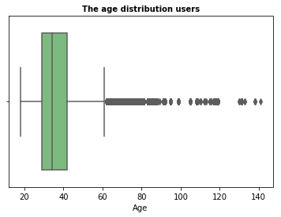

```python
g=sb.boxplot(x='member_age', data=ford_df_copy, palette='Greens', orient='h')
g.set_title("The age distribution users", fontsize=10, fontweight="bold")
g.set_xlabel("Age")
```

> It can be observed that 90% of the Users are under the age of 60, so it can be considered the users above the age of 60 to be outliers and hence remove them

```python
ford_df_copy = ford_df_copy[ford_df_copy['member_age']<=60]
```

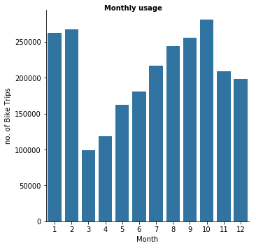

```python
# Monthly usage
base_color=sb.color_palette()[0]
g = sb.catplot(data=ford_df_copy, x='st_month_#', kind='count', color = base_color)
g.set_axis_labels("Month", "no. of Bike Trips")
g.fig.suptitle('Monthly usage', fontsize=10, fontweight="bold");
```

This data shows us that there are two peaks in the demand of bikes in the initial two months and then high demand being in the months from May-october.  
The high numbers in the first two months mayalso be because the data in 2019 has the data of only these two months.

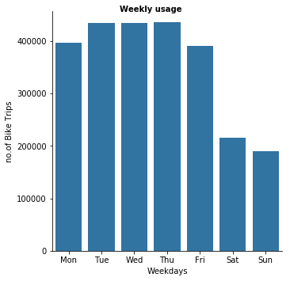

```python
#Weekly usage
week = ['Mon', 'Tue', 'Wed', 'Thu', 'Fri', 'Sat', 'Sun']
g1= sb.catplot(data=ford_df_copy, x='st_weekday', kind='count', color = base_color, order = week)
g1.set_axis_labels("Weekdays", "no.of Bike Trips")
g1.fig.suptitle('Weekly usage', fontsize=10, fontweight="bold");
```

The Usage is more during the week than the Weekends. Probably because the system is being used fordaily commute.

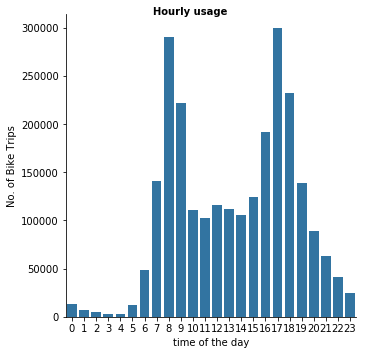

```python
#Hourly usage
g = sb.catplot(data=ford_df_copy, x='st_hr', kind='count', color = base_color)
g.set_axis_labels("time of the day", "No. of Bike Trips")
g.fig.suptitle('Hourly usage', fontsize=10, fontweight='bold');
```

> Most bikes are being rented in the hours 7-10am in the monring and again from another rise we can see at around 4-7pmin the evening.So as we saw from the weekly graph, the trend must be because the system is being used mostly for commuting.

### Bivariate

#### What share of the bikes are rented by a customer and what share are rented by a subscriber?

```python
customer = ford_df_copy.query("user_type== 'Customer'")['bike_id'].count()
subscriber =ford_df_copy.query('user_type == "Subscriber"')['bike_id'].count()
```

```python
customer_prop=customer/ford_df_copy.bike_id.count()
subscriber_prop=subscriber/ford_df_copy.bike_id.count()
```

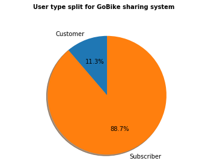

```python
labels = ['Customer', 'Subscriber']
sizes = [customer_prop, subscriber_prop]
#explode = (0, 0.1)

plt.pie(sizes, labels=labels,autopct='%1.1f%%', shadow=True, startangle=90)
plt.axis('equal')

plt.suptitle('User type split for GoBike sharing system', y=1.03, fontsize=10, fontweight='bold');
```

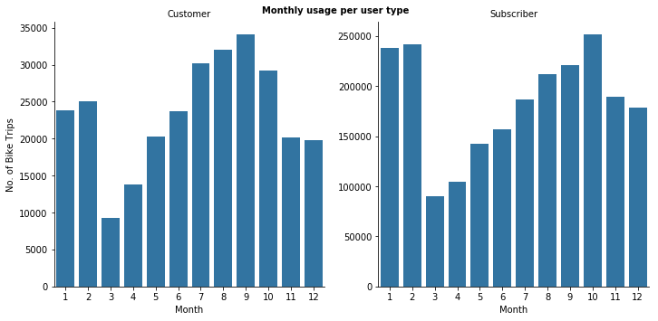

```python
g = sb.catplot(data=ford_df_copy, x="st_month_#", col="user_type", kind="count",sharey=False, color=base_color)
g.set_titles("{col_name}")
g.set_axis_labels("Month", "No. of Bike Trips")
g.fig.suptitle('Monthly usage per user type', fontsize=10, fontweight='bold');
```

> Clearly for the CUSTOMER renting the bikes on a rise in the period between the months of May-september,with a peak in September. Those are the summer months in the Bay area. Customers are most probably occasional riders or tourist coming to visit the Bay Area. For the Subscribers, the rise demand is between the months May-October, reaching it's peak in October. Subscribers are most probably regular riders using bikes for a daily commute.

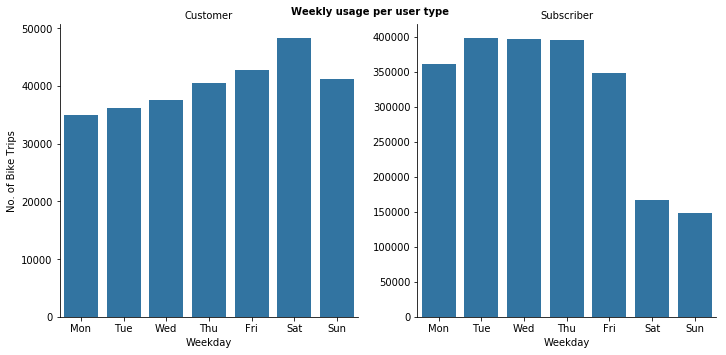

```python
order=["Mon","Tue","Wed","Thu","Fri","Sat","Sun"]
g = sb.catplot(data=ford_df_copy, x="st_weekday", col="user_type", kind="count",
               sharey=False, color=base_color, order=order)
g.set_titles("{col_name}")
g.set_axis_labels("Weekday", "No. of Bike Trips")
g.fig.suptitle('Weekly usage per user type', fontsize=10, fontweight='bold');
```

> As observed before the CUSTOMER being an occational user, probably a tourist, there is a trend of high usage by them in the weekends. Where as SUBSCRIBER has the trend of high usage in the weekdays, most probably for daily commute.

```python
trip_by_hour_df = ford_df_copy.groupby(['st_hr','user_type']).agg({'bike_id':'count'}).reset_index()
```

```python
trip_by_hour_df['bike_id'] = (trip_by_hour_df['bike_id']/trip_by_hour_df['bike_id'].sum())*100
```

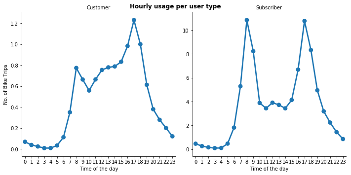

```python
g = sb.catplot(data=trip_by_hour_df, x="st_hr",y='bike_id', col="user_type", kind="point",sharey=False, color=base_color)
g.set_axis_labels("Time of the day", "No. of Bike Trips")
g.set_titles("{col_name}")
g.fig.suptitle('Hourly usage per user type', fontsize=12, fontweight='bold');
```

> From this observation CUSTOMERS use bikes mainly between 8 am - 7 pm, reaching the renting peak around 5pm, mostly to explore the area for the whole day. SUBSCRIBERS on the other side have two times in the day where the usage is very high, at around 8-9am and 5-6pm when they go and come back from work.

### Multivariate

> In this section I will further explore which age group mostly uses the system in both Customer and Subscriber category and check the hourly distribution of bike rides during weekdays.

#### Aggregate of riders as per Age groups.

```python
ford_df_copy.member_age_bins.dropna()
age_df=ford_df_copy.groupby('member_age_bins').agg({'bike_id':'count'})
```

```python
age_df["percent"]=(age_df['bike_id']/age_df['bike_id'].sum())*100
```

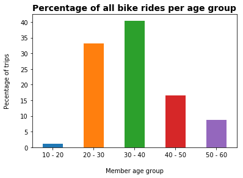

```python
age_df.percent.plot( x='percent',kind='bar');
plt.title('Percentage of all bike rides per age group', fontsize=14, fontweight="bold")
plt.xlabel('Member age group', labelpad=16)
plt.ylabel('Pecentage of trips', labelpad=16)
plt.xticks(rotation=360);
```

#### Monthly usage of bikes as per age group of each type of user.

```python
age_user_df=ford_df_copy.groupby(['member_age_bins','user_type','st_month_#']).agg({'bike_id':'count'}).reset_index()
```

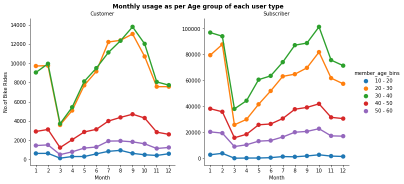

```python
g = sb.catplot(data=age_user_df, x='st_month_#',y='bike_id', col="user_type",
               hue='member_age_bins',kind="point",sharey=False);
g.fig.suptitle("Monthly usage as per Age group of each user type", fontsize=12, fontweight="bold",y=1.015)
g.set_axis_labels('Month','No.of Bike Rides')
g.set_titles("{col_name}");
```

> The most prevelent age group in the category of customers of user type is the group of people from the age 20-40. Where as in subscribers the group of 30-40 seems to use the bikes more than any other group.It can also be inferred from that graph that overall they follows the same trend of usage is same as that of the population ie of high usage in the months of summer.

```python
age_user_df=ford_df_copy.groupby(['member_age_bins','user_type','st_hr']).agg({'bike_id':'count'}).reset_index()
```

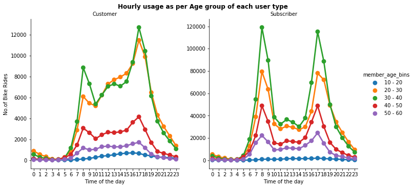

```python
g = sb.catplot(data=age_user_df, x='st_hr',y='bike_id', col="user_type",
               hue='member_age_bins',kind="point",sharey=False);
g.fig.suptitle("Hourly usage as per Age group of each user type", fontsize=12, fontweight="bold",y=1.015)
g.set_axis_labels('Time of the day','No.of Bike Rides')
g.set_titles("{col_name}");
```

> In case of Customer the age groups 20-30and 30-40, are significantly use more bikes throughout the day than the other groups. Where as in a Subscriber the group 30-40 is a higher user.  
> So we can analyse the groups of 20-40 more closely.

```python
hour_df_sub = ford_df_copy[(ford_df_copy['member_age']>=20)&(ford_df_copy['member_age']<40)
                       &(ford_df_copy['st_hr']>5)&(ford_df_copy['user_type']=='Subscriber')
                      ].groupby(['st_weekday','st_hr']).agg({'bike_id' : 'count'}).rename(columns={'bike_id':'count'}).reset_index()
hour_df_sub['st_weekday'] = pd.Categorical(hour_df_sub['st_weekday'], categories=['Mon','Tue','Wed','Thu','Fri','Sat', 'Sun'], ordered=True)
```

```python
hour_df_sub['count_perc'] =hour_df_sub['count'].apply(lambda x: (x/hour_df_sub['count'].sum())*100)
```

```python
hour_df_sub['rank'] = hour_df_sub['count_perc'].rank(ascending=False).astype(int)
```

```python
hour_df_sub_pivoted = hour_df_sub.pivot_table(index='st_hr', columns='st_weekday', values='rank')
```

```python
hour_df_cust = ford_df_copy[(ford_df_copy['member_age']>=20)&(ford_df_copy['member_age']<40)
                       &(ford_df_copy['st_hr']>5)&(ford_df_copy['user_type']=='Customer')
                      ].groupby(['st_weekday','st_hr']).agg({'bike_id' : 'count'}).rename(columns={'bike_id':'count'}).reset_index()
hour_df_cust['st_weekday'] = pd.Categorical(hour_df_cust['st_weekday'], categories=['Mon','Tue','Wed','Thu','Fri','Sat', 'Sun'], ordered=True)
```

```python
hour_df_cust['count_perc'] =hour_df_cust['count'].apply(lambda x: (x/hour_df_cust['count'].sum())*100)
```

```python
hour_df_cust['rank'] = hour_df_cust['count_perc'].rank(ascending=False).astype(int)
```

```python
hour_df_cust_pivoted = hour_df_cust.pivot_table(index='st_hr', columns='st_weekday', values='rank')
```

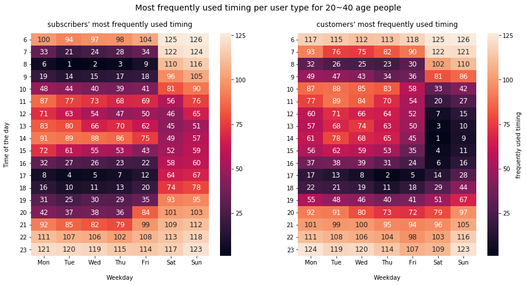

```python
plt.figure(figsize=(15,7))
plt.subplot(121)
plt.suptitle('Most frequently used timing per user type for 20~40 age people', fontsize=14)
sb.heatmap(hour_df_sub_pivoted, annot=True,fmt='d', annot_kws={"size": 12});
plt.title("subscribers' most frequently used timing", y=1.015)
plt.xlabel('Weekday', labelpad=16)
plt.ylabel('Time of the day', labelpad=16)
plt.yticks(rotation=360);
plt.subplot(122)
sb.heatmap(hour_df_cust_pivoted, annot=True,fmt='d', annot_kws={"size": 12}, cbar_kws={'label': 'frequently used timing'});
plt.title("customers' most frequently used timing", y=1.015)
plt.xlabel('Weekday', labelpad=16)
plt.ylabel(' ');
plt.yticks(rotation=360);
```

> Subscribers are most frequently used this service around 7-9am and 4-6pm. Customers are used this service at weekend around 10am-5pm and weekday 5pm-6pm. Customers use this service during weekend for leisure and weekdays after work.